# Intro to mixed effects models

1 May 2020

## Goals for today

- Understand the difference between fixed and random effects
- Understand reasons to use random effects models
- Understand the benefits & costs of random effects models

## Forms of linear models

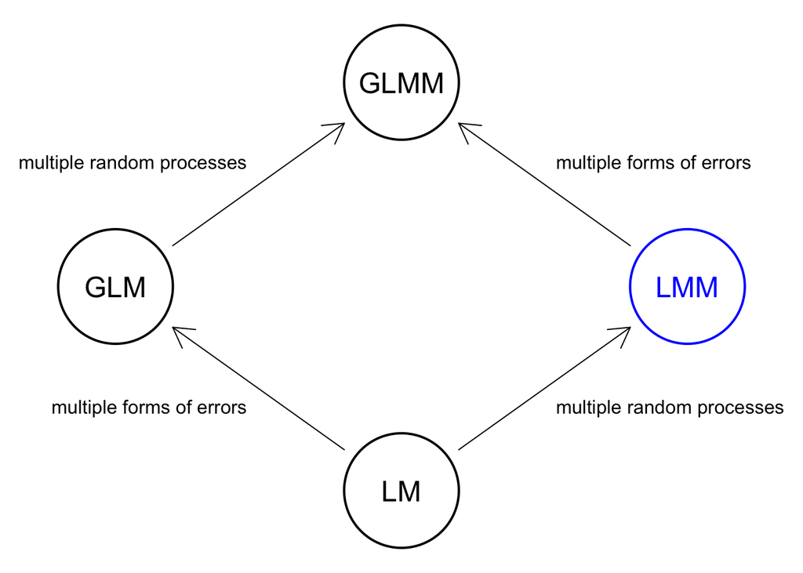

## Terminology

Mixed effects models are known by many names

- Variance components models
- Random effects models
- Varying coefficients models
- Hierarchical linear models
- Multilevel models

## Why use linear mixed models?

- Ecological data are often messy, complex, and incomplete
- Data are often grouped by location, species, etc
- May have multiple samples from the same individual
- Often small sample sizes for some locations, species, etc

## Fixed vs random effects

**fixed factor**: *qualitative* predictor (eg, sex)

**fixed effect**: *quantitative* change (“slope”)

## Fixed vs random effects

**fixed factor**: *qualitative* predictor (eg, sex)

**fixed effect**: *quantitative* change (“slope”)

**random factor**: *qualitative* predictor whose levels are randomly sampled from a population (eg, age)

**random effect**: *quantitative* change whose levels are randomly sampled from a population

## Fixed vs random effects

Fixed effects describe *specific levels* of factors that are *not* part of a larger group

## Fixed vs random effects

Fixed effects describe *specific levels* of factors that are *not* part of a larger group

Random effects describe *varying levels* of factors drawn from a larger group

## Fixed vs random effects

**Fixed effects**

- nutrient added or not
- female vs male
- wet vs dry

**Random effects**

- genotype
- plot within a forest
- genus within family

## Random effects

Random effects occur in 3 circumstances

1. nested (hierarchical) studies

(eg, fish within lakes, multiple lakes within a state)

## Random effects

Random effects occur in 3 circumstances

1. nested (hierarchical) studies
2. time series (longitudinal) studies

(eg, repeated measurements from the same place or individual)

## Random effects

Random effects occur in 3 circumstances

1. nested (hierarchical) studies
2. time series (longitudinal) studies
3. spatial studies

(eg, multiple trees within a plot)

## Fixed vs random effects

Fixed effects influence only the **mean** of \(y\)

Random effects influence only the **variance** of \(y\)

## A linear model (ANCOVA)

Fish mass as a function of its length and *specific* lake

\[ y_{i,j} = \underbrace{\alpha + \beta x_{i,j} + \delta_{j}}_{\text{fixed}} + \underbrace{\epsilon_{i,j}}_{\text{random}} \]

\(y_i\) is the log(mass) for fish *i* in lake \(j\)

\(x_i\) is the log(length) for fish *i* in lake \(j\)

\(\delta_j\) is the mean log(mass) of fish in lake \(j\)

\(\epsilon_{i,j} \sim \text{N}(0,\sigma_\epsilon)\)

## A linear mixed model

Fish mass as a function of its length and *general* lake

\[ y_{i,j} = \underbrace{\alpha + \beta x_{i,j}}_{\text{fixed}} + \underbrace{\delta_{j} + \epsilon_{i,j}}_{\text{random}} \]

\(y_i\) is the log(mass) for fish *i* in lake \(j\)

\(x_i\) is the log(length) for fish *i* in lake \(j\)

\(\delta_j\) is the mean log(mass) of fish in lake \(j\)

\(\epsilon_{i,j} \sim \text{N}(0,\sigma_\epsilon) ~ \text{and} ~ \delta_{j} \sim \text{N}(0,\sigma_\delta)\)

[Michael Freeman’s visualization](http://mfviz.com/hierarchical-models/)

## Five fundamental assumptions

- Within-group errors are *independent* with mean zero and variance \(\sigma^2\)
- Within-group errors are *independent of the random effects*
- Random effects are normally distributed with mean zero and covariance \(\Psi\)
- Covariance matrix \(\Psi\) *does not depend* on the level
- Random effects are *independent* among different levels

## Levels of random effects

In many cases, we can have multiple *levels* of random effects

trees within plots within forests within regions within states

## Tricks to random effects

- learning which variables are random effects
- correctly specifying the fixed and random effects in a model
- getting the nesting structure correct

## Questions about random effects

### Experimental design

Where does most of the variation occur & where would increased replication help?

## Questions about random effects

### Hierarchical structure

What are the different levels of variation?

## Pseudoreplication

To qualify as *true replicates*, measurements must

- be independent
- not be part of a time series
- not be grouped in together in one place
- not be repeated on the same subject

## Pseudoreplication

### An example

Imagine a field experiment to test insecticide effects on plant2

- 20 plots: 10 sprayed & 10 unsprayed
- 50 plants within each plot
- each plant is measured 5 times

## Pseudoreplication

### An example

Imagine a field experiment to test insecticide effects on plants

- 20 plots: 10 sprayed & 10 unsprayed
- 50 plants within each plot
- each plant is measured 5 times

What are the degrees of freedom?

20 \(\times\) 50 \(\times\) 5 = 5000 (?)

## Pseudoreplication

### An example

Imagine a field experiment to test insecticide effects on plants

- 20 plots: 10 sprayed & 10 unsprayed
- 50 plants within each plot
- each plant is measured 5 times

What are the degrees of freedom?

20 \(\times\) 50 \(\times\) 5 = 5000 (?)

2 \(\times\) 9 = 18 (!)

## Model for means

Consider a simple one-way ANOVA model

\[ y_{ij} = \mu + \alpha_j + \epsilon_{ij} \\ \epsilon_{ij} \sim \text{N}(0, \sigma^2_{\sigma}) \]

where the group-level means \(\alpha_j\) are *fixed*

## Model for means

Now consider this one-way ANOVA model

\[ y_{ij} = \mu + \alpha_j + \epsilon_{ij} \\ \epsilon_{ij} \sim \text{N}(0, \sigma^2_{\sigma}) \\ \alpha_j \sim \text{N}(0, \sigma^2_{\alpha}) \]

where the group-level means \(\alpha_j\) are *random*

## Distribution of means

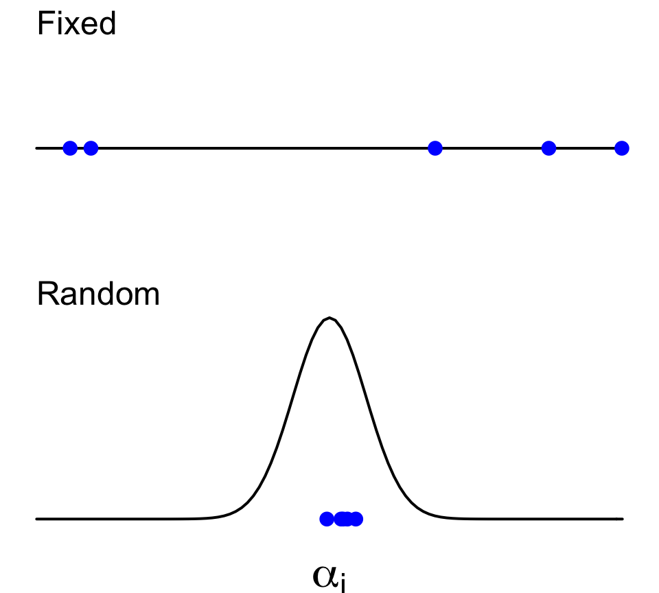

## Intraclass correlation

The means in the fixed effect model are independent

The means in the random effects model are correlated

## Intraclass correlation

The means in the fixed effect model are independent

The means in the random effects model are correlated

\[ \rho = \frac{\sigma^2_{\alpha}}{\sigma^2_{\alpha} + \sigma^2_{\epsilon}} \]

The correlation depends on the relative size of \(\sigma^2_{\alpha}\) vs \(\sigma^2_{\epsilon}\)

## Group means

In fixed effects models, the group means are

\[ \alpha_j = \bar{y} - \mu \]

## Shrinkage of group means

In fixed effects models, the group means are

\[ \alpha_j = \bar{y} - \mu \]

In random effects models, the group means “shrink” towards one another

\[ \alpha_j = (\bar{y} - \mu) \left( \frac{\sigma^2_{\alpha}}{\sigma^2_{\alpha} + \sigma^2_{\epsilon}} \right) \]

## Shrinkage

Consider what happens to \(\alpha_j\) as \(\sigma^2_{\alpha} \rightarrow \infty\)

\[ \alpha_j = (\bar{y} - \mu) \left( \frac{\sigma^2_{\alpha}}{\sigma^2_{\alpha} + \sigma^2_{\epsilon}} \right) \\ \Downarrow \\ \begin{aligned} \alpha_j &= (\bar{y} - \mu) \left( \frac{\infty}{\infty + \sigma^2_{\epsilon}} \right) \\ &= \bar{y} - \mu \end{aligned} \]

## Shrinkage

As \(\sigma^2_{\alpha} \rightarrow \infty\), our random effects become increasingly independent

\[ \alpha_j \sim \text{N}(0, \sigma^2_{\alpha}) \\ \Downarrow \\ \alpha_j \sim \text{Unif}(-\infty, \infty) \]

## Benefits

- Broadens our inference to a larger population
- Larger groups inform smaller groups (“Robin Hood Effect”)

## Benefits

- Broadens our inference to a larger population
- Larger groups inform smaller groups (“Robin Hood Effect”)
- Represents a “compromise” in terms of information used
  - fixed effects: no grouping (“no pooling”)
  - random effects: some grouping (“partial pooling”)
  - none: all one group (“complete pooling”)

## Costs

- Precision decreases with number of levels
- Random effects perhaps more difficult to explain